# L10 Faceting

Data Visualization (STAT 302)

Noah Holubow

```r
library(knitr)
opts_chunk$set(warning = FALSE, message = FALSE, comment = FALSE, dpi = 300)
```

## Overview

The goal of this lab is to do a little practice with facets (small multiples) and provide and opportunity to try out using non-standard fonts.

## Datasets

We’ll be using the `cdc.txt` dataset.

```r
# Load package(s)
library(tidyverse)
library()

# Load datasets
cdc <- read_delim(file = "data/cdc.txt", delim = "|") %>%
  mutate(genhlth = factor(genhlth,
    levels =  c("poor", "fair", "good", "very good", "excellent"),
    labels = c("Poor", "Fair", "Good", "Very Good", "Excellent")
  ))

# Set seed
set.seed(2468)

cdc_small <- cdc %>%
  slice_sample(n = 1000)
```

## Exercises

Complete the following exercises.

### Exercise 1

Using `cdc_small` construct a the following graphic as precisely as possible.

*Hints:*

- Example in assigned reading
- Hex values: `"#D55E00"` (women) and `#0072B2` (men)
- `grey85` might be useful
- size 2

**Answer:**

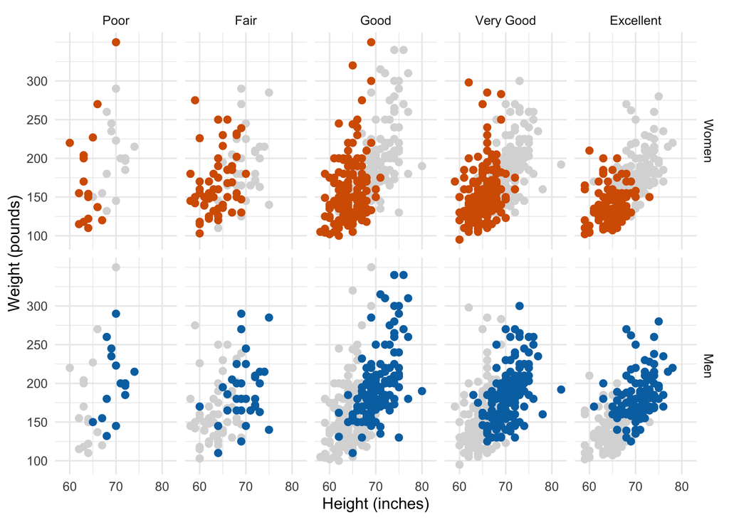

```r
# preparing dataset
cdc_small_2 <- dplyr::select(cdc_small, -gender)

# gender titles
gender_labs <- c("Women", "Men")
names(gender_labs) <- c("f", "m")

# plot
cdc_small %>%
  ggplot(aes(x = height, y = weight)) +
  geom_point(data = cdc_small_2, color = "grey85", size = 2) +
  geom_point(aes(color = gender), size = 2) +
  facet_grid(gender ~ genhlth,
             labeller = labeller(gender = gender_labs)
             ) +
  scale_color_manual(values = c("#D55E00", "#0072B2")) +
  labs(
    x = "Height (inches)",
    y = "Weight (pounds)"
  ) +
  scale_x_continuous(breaks = seq(60, 80, by = 10)) +
  scale_y_continuous(breaks = seq(100, 300, by = 50)) +
  theme_minimal() +
  theme(
    legend.position = "none"
  )
```

### Exercise 2

**Must haves:**

- Use two non-standard fonts (one for labeling the point and the other for the axes)
- Use at least two colors (one for the added point, another for the rest of the points)
- A curved arrow used to label the point

Using Bilbo Baggins’ responses below to the CDC BRSFF questions, add Bilbo’s data point to a scatterplot of `weight` by `height`.

- `genhlth` - How would you rate your general health? **fair**
- `exerany` - Have you exercised in the past month? **1=yes**
- `hlthplan` - Do you have some form of health coverage? **0=no**
- `smoke100` - Have you smoked at least 100 cigarettes in your life time? **1=yes**
- `height` - height in inches: **46**
- `weight` - weight in pounds: **120**
- `wtdesire` - weight desired in pounds: **120**
- `age` - in years: **45**
- `gender` - m for males and f for females: **m**

Adding non-standard fonts can be an *adventure*. I find this [blog post](https://cran.rstudio.com/web/packages/showtext/vignettes/introduction.html) to be extremely useful. We are likely to play around with this in class so you will want to follow along. Important packages for using non-standard fonts are `showtext`, `extrafont`, `extrafontdb`, and `sysfonts`. The last 3 generally just need to be installed (not loaded per session).

*Hint:*

- Create a new dataset (maybe call it `bilbo` or `bilbo_baggins`) using either `data.frame()` (base R - example in book) or `tibble()` (tidyverse - see help documentation for the function). Make sure to use variable names that exactly match `cdc`’s variable names
- Search google fonts to find some free fonts to use (can get free fonts from other locations)

**Answer:**

[figure not shown]

```r
# font packages
library(showtext)
font_add_google("Gochi Hand", "gochi")
font_add_google("Schoolbell", "bell")
showtext_auto()

# Bilbo data
bilbo_baggins <- tibble(
  genhlth = "fair",
  exerany = 1,
  hlpthplan = 0,
  smoke100 = 1,
  height = 46,
  weight = 120,
  wtdesire = 120,
  age = 45,
  gender = "m"
)

# graph
cdc_small %>%
  ggplot(aes(height, weight)) +
  geom_point(color = "blue", alpha = 0.2, size = 2) +
  scale_alpha_continuous() +
  geom_point(data = bilbo_baggins, color = "red") +
   labs(
    x = "Height (in)",
    y = "Weight (lbs)"
  ) +
  annotate(
    "text",
    55,
    350,
    label = "Bilbo Baggins",
    family = "bell",
    fontface = "italic",
    size = 12,
    color = "red") +
  annotate(
    geom = "curve",
    color = "red",
    x = 54,
    y = 340,
    xend = 46,
    yend = 125,
    curvature = .3,
    arrow = arrow(length = unit(2, "mm"))
  ) +
  scale_y_continuous(breaks = seq(100, 400, by = 100), limits = c(100, 400)) +
  theme_minimal() +
  theme(
    axis.title.x = element_text(family = "gochi"),
    axis.title.y = element_text(family = "gochi")
  )
```